# Evaluating the Use of a Mortality Score in Admitting Covid-19 Patients into Dutch Hospitals

Adam Maghout

a.maghout@uu.nl

Methodology & Statistics @ UU University

19 Feb 2025

## Background

- Development and validation of a pragmatic risk score to predict in-hospital mortality in patients admitted to hospital with covid-19.
- Analysis conducted in December 2021.
- In 2021 up until December, 1 870 640 new reported cases of covid-19 and 8 109 reported deaths (“COVID-19 Data WHO COVID-19 Dashboard” n.d.).
- Important to hospitalise at-risk patients without overburdening healthcare facilities.

## Data

Data is based on a prospective observational cohort study from Knight et al. (2020) in 260 hospitals across England, Scotland, and Wales, on adults (age ≥18 years) admitted to hospital between 6 February 2020 and 29 June 2020 with covid-19.

Although the original study included 35 463 patients in the derivation dataset and 22 361 in the validation dataset, the current dataset comprises of only:

3546 patients in the derivation set  
2236 patients in the validation set

## Data

- `rr`: respiratory rate breaths/min.
- `oxygen_sat`: peripheral oxygen saturation in %.
- `urea`: urea level in mm/L.
- `crp`: C reactive protein in mg/L.
- `gcs`: level of consciousness on the Glasgow coma scale.
- `age`: age in years.
- `female`: sex (female = 1, male = 0).
- `comorbidity`: number of comorbidities, including obesity, chronic cardiac disease, etc.
- `date`: unit unclear.
- `set`: identifier for the development and validation sets.
- `mortality`: in-hospital mortality during study.

| **Characteristic** | **N = 5,782**<sup>1</sup> |
| --- | --- |
| rr | 26 (20, 33) |
| oxygen_sat | 91.0 (87.0, 95.0) |
| urea | 10 (5, 20) |
| crp | 98 (49, 189) |
| gcs | 15.00 (15.00, 15.00) |
| age | 74 (61, 85) |
| female |  |
| 0 | 3,360 (58%) |
| 1 | 2,422 (42%) |
| comorbidity |  |
| 0 | 1,361 (24%) |
| 1 | 1,602 (28%) |
| 2 | 2,819 (49%) |
| date | 43,952 (43,909, 43,986) |
| set |  |
| dev | 3,546 (61%) |
| val | 2,236 (39%) |
| mortality |  |
| 0 | 3,527 (61%) |
| 1 | 2,255 (39%) |

<sup>1</sup> Median (Q1, Q3); n (%)

## Aims

- Fitting a logistic model to predict `mortality` from the other variables.
- Conduct a Decision Curve Analysis (DCA) to evaluate the net benefit (NB) of using the model.
- Obtain the Expected Value of Perfect Information (EVPI) of the model.

## Aims

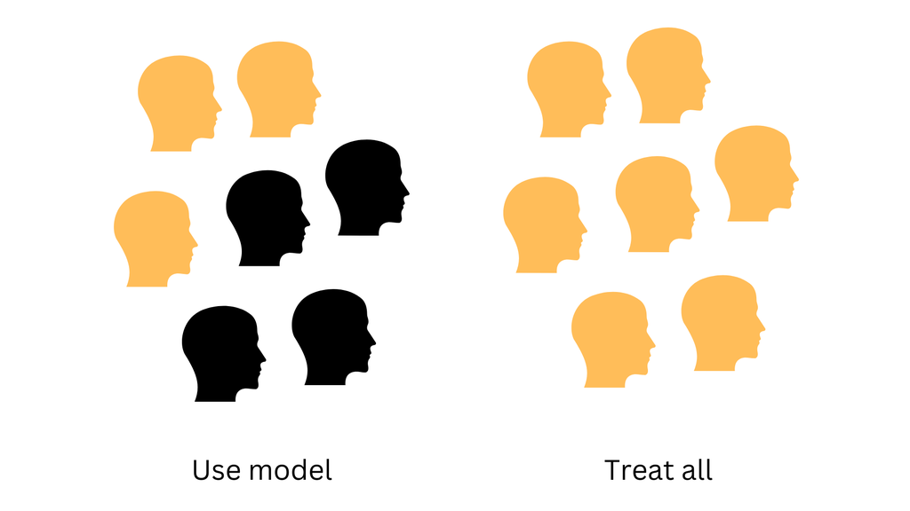

## Logistic Model

```r
model <- glm(mortality ~ age + female + comorbidity +
               rr + oxygen_sat + gcs + urea + crp,
             data = train,
             family = binomial)
summary(model)
```

```
Call:
glm(formula = mortality ~ age + female + comorbidity + rr + oxygen_sat +
    gcs + urea + crp, family = binomial, data = train)

Coefficients:
              Estimate Std. Error z value Pr(>|z|)
(Intercept)  0.2427317  0.7869210   0.308   0.7577
age          0.0463324  0.0027210  17.028  < 2e-16 ***
female      -0.1423915  0.0790909  -1.800   0.0718 .
comorbidity  0.3176072  0.0488476   6.502 7.93e-11 ***
rr           0.0286821  0.0046566   6.159 7.30e-10 ***
oxygen_sat  -0.0496440  0.0073009  -6.800 1.05e-11 ***
gcs         -0.1125824  0.0254772  -4.419 9.92e-06 ***
urea         0.0354867  0.0040457   8.772  < 2e-16 ***
crp          0.0026773  0.0004176   6.412 1.44e-10 ***
---
Signif. codes:  0 '***' 0.001 '**' 0.01 '*' 0.05 '.' 0.1 ' ' 1

(Dispersion parameter for binomial family taken to be 1)

    Null deviance: 4723.5  on 3545  degrees of freedom
Residual deviance: 3906.9  on 3537  degrees of freedom
AIC: 3924.9

Number of Fisher Scoring iterations: 4
```

## Temporal Validation

### Specificity, sensitivity, PPV and NPV

The model is now run on the validation set collected between 21 May and 29 June 2020.

```
Confusion Matrix and Statistics

          Reference
Prediction    0    1
         0 1134  421
         1  209  472

               Accuracy : 0.7182
                 95% CI : (0.6991, 0.7368)
    No Information Rate : 0.6006
    P-Value [Acc > NIR] : < 2.2e-16

                  Kappa : 0.3884

 Mcnemar's Test P-Value : < 2.2e-16

            Sensitivity : 0.8444
            Specificity : 0.5286
         Pos Pred Value : 0.7293
         Neg Pred Value : 0.6931
             Prevalence : 0.6006
         Detection Rate : 0.5072
   Detection Prevalence : 0.6954
      Balanced Accuracy : 0.6865

       'Positive' Class : 0
```

## Temporal Validation

### Calibration plot

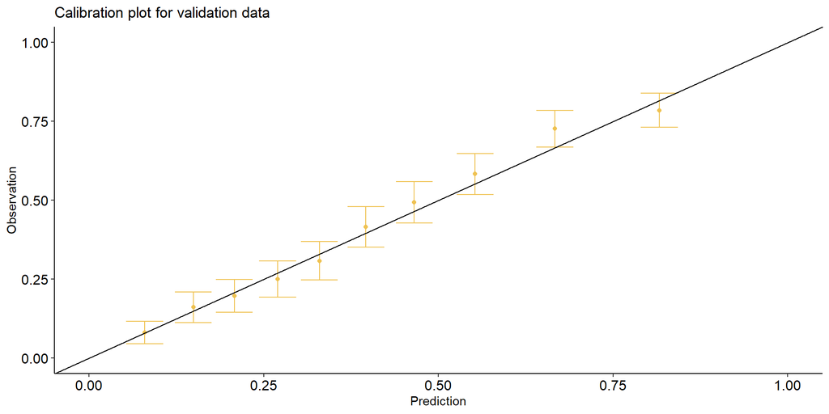

## Decision Curve Analysis

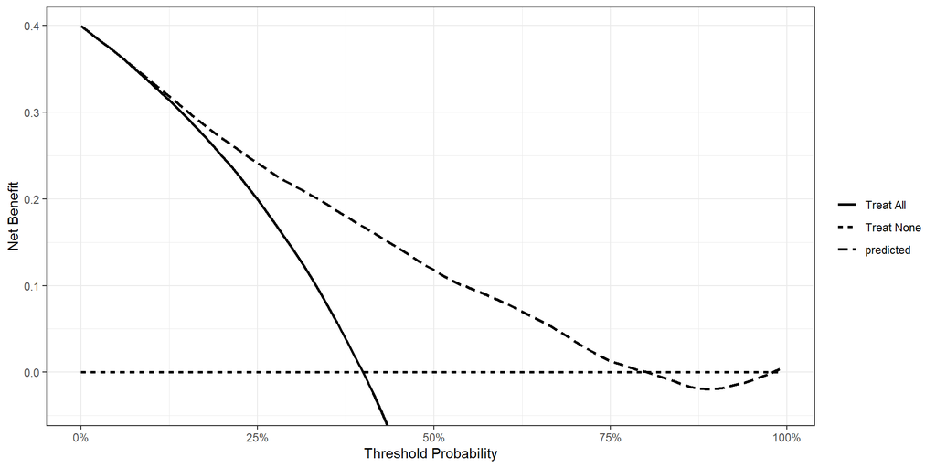

## Decision Curve Analysis

Assuming that the risk threshold `z` above which patients are admitted to ICU is 10%:

```r
dca_an %>%
  as_tibble() %>%
  filter(threshold %in% seq(0.05, 0.15, by = 0.05)) %>%
  dplyr::select(variable, threshold, net_benefit) %>%
  pivot_wider(id_cols = threshold,
              names_from = variable,
              values_from = net_benefit)
```

```
# A tibble: 3 × 4
  threshold   all  none predicted
      <dbl> <dbl> <dbl>     <dbl>
1      0.05 0.368     0     0.368
2      0.1  0.333     0     0.336
3      0.15 0.293     0     0.302
```

The net benefit of using the model is **0.003**.

## Decision Curve Analysis

### Implications of the net benefit

The NB is defined as the proportion of additional true positives identified and:

$$TP = \frac{z}{1-z}FP$$

For 1000 patients:

```r
NB*1000 # gain in true positives
```

```
[1] 3
```

```r
((1-z)/z)*NB*1000 # reduction in false positives
```

```
[1] 27
```

For 1 870 640 patients:

```r
NB*1870640 # gain in true positives
```

```
[1] 5611.92
```

```r
((1-z)/z)*NB*1870640 # reduction in false positives
```

```
[1] 50507.28
```

## Decision Curve Analysis

### Decision

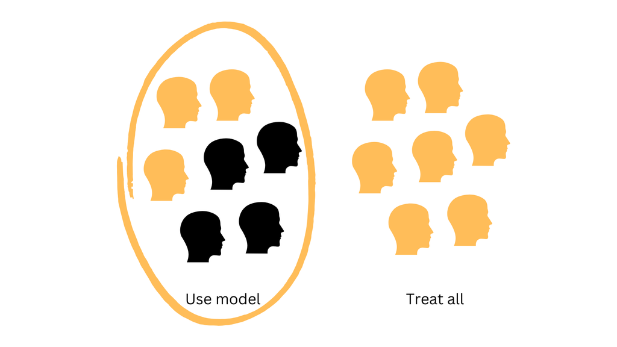

## Value-of-information

### Expected Value of Perfect Information (EVPI)

An EVPI indicates how much NB is expected to be lost due to the model being imperfect. Sadatsafavi et al. (2023) propose several ways to compute it:

- Bayesian bootstrapping
- Ordinary bootstrapping
- Asymptotic approach based on central limit theorem

## Value-of-information

### Analysis

```r
n <- nrow(test)

#Step 1: store predicted probabilities.
pi <- test$predicted

#Step 2: The bootstrap Monte Carlo simulation
set.seed(123)
N <- 10000
NBmodel <- NBall <- rep(0,N)
for(i in 1:N) {
  bsdata <-  test[sample(1:n, n, replace = T),]
  NBall[i] <- mean(bsdata$mortality-(1-bsdata$mortality)*z/(1-z))
  NBmodel[i] <- mean((bsdata$predicted>z)*(bsdata$mortality-(1-bsdata$mortality)*z/(1-z)))
}

#Step 3: EVPI calculation
EVPI <- mean(pmax(0,NBmodel,NBall))-max(0,mean(NBmodel),mean(NBall))
EVPI
```

```
[1] 1.131485e-05
```

## Value-of-information

### Decision

For 1000 patients:

```r
EVPI*1000 # gain in true positives
```

```
[1] 0.01131485
```

```r
((1-z)/z)*EVPI*1000 # reduction in false positives
```

```
[1] 0.1018336
```

For 1 870 640 patients:

```r
EVPI*1870640 # gain in true positives
```

```
[1] 21.16601
```

```r
((1-z)/z)*EVPI*1870640 # reduction in false positives
```

```
[1] 190.4941
```

Given the cost of additional research, both in terms of time wasted to use the model and in financial costs, additional research seems unnecessary.

## Final Decision

The findings support the use of the mortality prediction score to aid ICU admission decisions in Dutch hospitals.

Given the minimal expected benefit from further external validation, resources may be better allocated to implementation and refinement of the model rather than additional validation studies.

## Challenges

- Decisions seem arbitrary without additional financial aspects.
- Confusion concerning how the model can be relevant given the minimal sample size.
- Difficulties following the calculations presented in the recommended paper.
- Confusion surrounding the difference between an ordinary and a Bayesian bootstrap.
- Eager to undertake potential challenges associated with the EVSI but don’t know where to start.

## Bibliography

[figure not shown]

Adam Maghout @ UU

“COVID-19 Data WHO COVID-19 Dashboard.” n.d. *Datadot*. https://data.who.int/dashboards/covid19/data. Accessed February 16, 2025.

Knight, Stephen R., Antonia Ho, Riinu Pius, Iain Buchan, Gail Carson, Thomas M. Drake, Jake Dunning, et al. 2020. “Risk Stratification of Patients Admitted to Hospital with Covid-19 Using the ISARIC WHO Clinical Characterisation Protocol: Development and Validation of the 4C Mortality Score.” *BMJ* 370 (September): m3339. https://doi.org/10.1136/bmj.m3339.

Sadatsafavi, Mohsen, Tae Yoon Lee, Laure Wynants, Andrew J. Vickers, and Paul Gustafson. 2023. “Value-of-Information Analysis for External Validation of Risk Prediction Models.” *Medical Decision Making: An International Journal of the Society for Medical Decision Making* 43 (5): 564–75. https://doi.org/10.1177/0272989X231178317.